# Phylogeny reconstruction workshop

## What is the evolutionary history of the virus causing covid-19?

This virtual workshop is meant to give you a taste of how evolutionary biologists reconstruct phylogenies. Sometimes, resolving the phylogeny is a meaningful exercise in and of itself. Here, you will build a phylogeny using genomic data from several coronaviruses including SARS-CoV2 (the virus that causes covid-19) and close relatives sampled in bat and pangolin host species to find out the pathway that is most likely to have led to the ongoing covid-19 pandemic.

I’ve written the workshop in R to keep software requirements consistent across different L2 modules (e.g., Research Skills, Behaviour, and Ecology all use R). Technically speaking, you could simply copy and paste the code as it appears in this document, without really having to think about what the functions are doing. However, I recommend carefully reading this document and exploring functions, for instance by looking up help pages (e.g.:`?plot()`), to understand why the code is written as it is.

## Part 0: Prepare your R working environment

*Note: This is written under the assumption that you are working within RStudio.*

First, install the packages ‘msa’ and ‘phangorn’ and ‘ape’, if you haven’t done so already

```r
if (!requireNamespace("BiocManager", quietly=TRUE))
install.packages("BiocManager")
BiocManager::install("msa")
install.packages(c("phangorn","ape"))
```

Load packages and a dataset that we will play around with

```r
require(msa)
require(ape)
require(phangorn)
```

Next, change your working directory to the folder that contains the files for today’s workshop by either going to “Session” > “Set Working Directory” > “Choose Directory…” or by using the command `setwd()`.

## Part 1: Load DNA sequences

Many different types of data can be used to build a phylogenetic tree. Two of the most common are morphological data and DNA sequences; indeed, some phylogenetic tree building approaches can even accommodate having both of these types of data in the same data set. We are going to use DNA sequences today. *Note: Actually, SARS-CoV2 is an RNA virus, but sequence data come from DNA transcriptions, hence the presence of “T”s in the sequences below.*

An important aspect of research is to give enough details in your scientific publication so that your work can be replicated and confirmed. For researchers collecting DNA sequence data, this means that the data must be deposited in online databases that are freely accessible, such as Genbank.

I have created a FASTA file (a file format used to store sequence information) with several coronavirus genomes in it, which I pulled together from data available on Genbank and on GISAID. Before loading the sequence data, take a look at Genbank by opening an internet browser and going to https://www.ncbi.nlm.nih.gov/. On the right, in a section called “Popular Resources” click on “Nucleotide”. You are now at the gateway to Genbank.

The virus that causes covid19 in humans is often referred to as SARS-CoV2 or hCoV-19. In the search bar, enter either of these terms. How many sequences are currently in Genbank?

In Genbank, each submission gets an identifier known as an “accession number.” One of the sequences we will analyse today has the accession number KY417145.1. Place this accession number in the search bar. What is the host species from which this virus was collected?

Table 1. Samples included in today’s workshop.

[output not shown]

Near the top of the page of the page, under the bold text “Bat SARS-like coronavirus isolate Rf4092.…” click on the link that says FASTA. The first line of a FASTA entry starts with a header line that contains `>` and has some information about the sequence (this occasionally wraps around so it appears as if it’s two lines, but it’s really just one). The DNA sequence itself starts on the next line.

I compiled sequences from a sample of several coronavirus genomes (Table 1) into a single FASTA file. Since each genome is ~29,000 bp, I trimmed the sequences so that the next steps take a bit less time. For more details on how this file was trimmed from the raw genome data, see below

Now that you see where you can obtain sequence data, let’s load in some coronavirus sequences.

```r
covid_region_B_msa<-readDNAStringSet("covid_region_B.fasta",format="fasta") #load DNA sequences stored in fasta file
```

## Part 2: Prepare sequence alignment

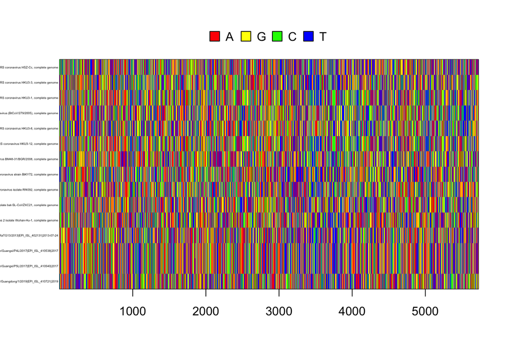

You will notice that the sequences do not line up – that is, the colours representing different nucleotides appear to be a massive jumble. Phylogeny building programs assume that all of the nucleotides in a column share an evolutionary history. In order for that to be true, we need to align the sequences so that homologous positions appear in the same column.

There are many different algorithms (sets of computational rules ‘that can be counted on–logically–to yield a certain sort of result whenever it is run’[^1]) that can efficiently identify homology across sequences. Today, we will use the “Muscle” algorithm. *Note: this next step may take a few minutes to finish running, so be patient.*

```r
covid_region_B_aligned<-msa(covid_region_B_msa,method="Muscle") #conduct alignment
```

Let’s take a look at the alignment:

```r
print(covid_region_B_aligned,show="complete")
```

Now, trim off the edges (i.e., NC_014470.1 starts at 199, MN908947.3 ends at 5776). *Note: you have to toggle between a few different package-specific formats of alignments to make this happen*

```r
covid_region_B_aligned_DNAbin<-as.DNAbin(covid_region_B_aligned) #change alignment to "DNAbin" format
covid_region_B_aligned_DNAbin_trimmed<-covid_region_B_aligned_DNAbin[,199:5776] #trim to the desired region
```

Make a plot of the resulting alignment, and compare it to the plot above of the unaligned matrix:

```r
image.DNAbin(covid_region_B_aligned_DNAbin_trimmed,cex=0.25) #plot alignment
```

[output not shown]

How does this compare to the plot of unaligned sequences above?

## Part 3: Tree building

Using this alignment, we will now reconstruct the phylogeny using two different techniques. *Note that there are other techniques possible as well, such as neighbor-joining and parsimony techniques, but we’ll just focus on two today.*

The first technique we will use is UPGMA (**U**nweighted **P**air **G**roup **M**ethod using the **A**rithmetic mean). As you will have seen in the mini-lecture, this technique is a distance-based method that builds a tree according to how similar the genetic sequences are to one another.

```r
covid_region_B_aligned_phyDat<-phyDat(covid_region_B_aligned_DNAbin_trimmed) #first, convert the alignment to a 'phyDat' object for use in the 'phangorn' package
upgma_tree<-upgma(dist.ml(covid_region_B_aligned_phyDat)) #now, build a tree using the upgma technique
plot(upgma_tree, cex=0.5) #plot this tree
```

[output not shown]

Even though R makes this tree appear rooted, in fact it is unrooted. Two outgroup sequences (from more distant coronavirus samples collected in Kenya [KY352407] and Bulgaria [NC_014470]; all other samples were collected in China) were included in the tree. Let’s re-root the tree with these as outgroup sequences.

```r
upgma_tree<-root(upgma_tree,c("KY352407.1 Severe acute respiratory syndrome-related coronavirus strain BtKY72, complete genome","NC_014470.1 Bat coronavirus BM48-31/BGR/2008, complete genome"))
plot(upgma_tree, cex=0.5) #plot this tree (cex controls the font size)
```

[output not shown]

In the UPGMA tree, which sequence is the closest relative to the SARS-CoV2 genome collected from a human in Wuhan (MN908947.3)?

Now we’ll turn to a ‘maximum likelihood’ approach. One downside to the UPGMA approach is that it just uses patterns of similarity to devise a tree. That is, it ignores the process of evolution that produced the tree in the first place! Another family of approaches aims to build trees by fitting models of nucleotide evolution to the sequence alginments. Briefly, this approach tries to figure out which phylogenetic tree is the most likely have generated a specified DNA alignment. By calculating the ‘likelihood’ of a large number of possible phylogenies, we can find the tree that is *most likely* to have generated our dataset under a given model–this is the ‘maximum likelihood’ tree.

Let’s find the maximum likelihood tree under a particular set of rules for nucleotide evolution. The “GTR” model is a commonly used model with six rates of evolutionary changes in nucleotides (see: https://en.wikipedia.org/wiki/Models_of_DNA_evolution#GTR_model_(Tavar%C3%A9_1986)). These rates are estimated alongside the phylogeny itself during the optimisation process. *Note: Be patient–this step takes several seconds*

```r
prelim_fit <- pml(upgma_tree, covid_region_B_aligned_phyDat) #initialise the likelihood optimisation
fitGTR <- optim.pml(prelim_fit, model = "GTR", rearrangement = "stochastic") #now run likelihood optimisation
```

You can see the estimated rates of evolution by looking at the ‘fitGTR’ object:

```r
print(fitGTR)
```

[output not shown]

Which nucleotide changes are most common? What about the least common?

But where is the phylogeny? In R, to examine the components of an object, you can use the `str()` function. Let’s take a look at the maximum likelihood object produced in `optim.pml()`

```r
str(fitGTR)
```

[output not shown]

As you can see, there is an element of this object called ‘tree’–this is the phylogeny. Let’s root and plot it as before:

```r
ml_gtr_tree<-root(fitGTR$tree,c("KY352407.1 Severe acute respiratory syndrome-related coronavirus strain BtKY72, complete genome","NC_014470.1 Bat coronavirus BM48-31/BGR/2008, complete genome")) #re-root the tree
plot(ml_gtr_tree, cex=0.5)
```

[output not shown]

How reasonable is this maximum likelihood phylogeny? One way of determining the reliability of a phylogeny is to conduct a ‘bootstrapping’ analysis. As you’ll recall from the mini-lecture, bootstrapping is a re-sampling technique, where columns in the alignment are sampled (with replacement) to create a new alignment. Then, the ML tree is recalculated, and the topology is recorded. The bootstrap support value at each node corresponds to the proportion of bootsrapped trees in which that relationship appears. For these support values, 70 is considered minimum acceptable support (although marginal), and values > 90 are considered strong support.

Let’s create 100 bootstrap replicates and plot the rooted tree with bootstrap values at the nodes:

```r
bs <- bootstrap.pml(fitGTR, bs=100, optNni=TRUE, multicore=TRUE, control = pml.control(trace=0))

plotBS(root(fitGTR$tree,c("KY352407.1 Severe acute respiratory syndrome-related coronavirus strain BtKY72, complete genome","NC_014470.1 Bat coronavirus BM48-31/BGR/2008, complete genome")), bs,p=0,type="p",cex=0.5)
```

[output not shown]

How does this tree compare to the UPGMA tree? Which sequence is the closest relative to the SARS-CoV2 genome collected from a human in Wuhan (MN908947.3)? How reliable is this inference?

Finally, to save the tree, along with bootstrap support values, in the “Newick” format (a typical way of saving a phylogeny):

```r
ml_gtr_tree_bootstrap<-plotBS(root(fitGTR$tree,c("KY352407.1 Severe acute respiratory syndrome-related coronavirus strain BtKY72, complete genome","NC_014470.1 Bat coronavirus BM48-31/BGR/2008, complete genome")), bs,p=0,type="p",cex=0.5)
write.tree(ml_gtr_tree_bootstrap,file="ml_gtr_tree_bootstrap.tree")
```

You could then reload this tree in the future using:

```r
ml_gtr_tree_bootstrap<-read.tree(file="ml_gtr_tree_bootstrap.tree")
plot(ml_gtr_tree_bootstrap,show.node.label=TRUE)
```

## Part 4: Questions

(…)

## Advanced sequence preparation: sampling genomes

For those of you who are curious about R, here’s a bit more info on how the sequence data were prepared.

First, read in the raw data–these are entire genome sequences of SARS-CoV viruses sampled in a number of species.

```r
covid<-read.dna("covid_fasta.fasta",format="fasta")
```

“Region B” is a non-recombining part of the genome (and therefore better suited to phylogenetic reconstruction), and is found around position 3625-9150[^2]. Rather than aligning the entire genomes (which is fairly computationally expensive), let’s just trim all sequences to positions 3500-9225 and write this to a new ‘fasta’ file.

```r
covid_region_B<-list()
for(i in 1:length(covid)){
    covid_region_B[[i]]<-covid[[i]][3500:9225]
}

names(covid_region_B)<-names(covid)
class(covid_region_B)<-"DNAbin"
```

Now save this as a .fasta file

```r
write.FASTA(covid_region_B,file="covid_region_B.fasta")
```

Now we’re ready to proceed with Part 1: Load DNA sequences above.

[^1]: From Daniel Dennett’s book *Darwin’s Dangerous Idea*. At the risk of getting carried away–this is also from that book: “The term *algorithm* descends, via Latin (*algorismus*) to early English (*algorisme* and, mistakenly therefrom, *algorithm*), from the name of a Persian mathematician, Mûusâ al-Khowârizm, whose book on arithmetical procedures, written about 835 A.D., was translated into Latin in the twelfth century by Adelard of Bath or Robert of Chester. The idea that an algorithm is a foolproof and somehow ‘mechanical’ procedure has been present for centuries, but it was the pioneering work of Alan Turing, Kurt Gödel, and Alonzo Church in the 1930s that more or less fixed our current understanding of the term.”
[^2]: Boni et al. bioRxiv (https://www.biorxiv.org/content/10.1101/2020.03.30.015008v1)